# DSCI 6607 – Final R Project – Fall 2023

Salman Yunus - 202292166

*Part-1 : An `Introduction’ section describing the dataset (and its background), describe statistically the types of the variables and what graphical displays and statistical measures are appropriate for the variables.*

**Introduction :**

The boneExam dataset is a valuable resource for researchers studying bone health and related factors in adults. The data was collected as part of the Third National Health and Nutrition Examination Survey (NHANES III), a large-scale study conducted by the Centers for Disease Control and Prevention (CDC) from 1988 to 1994. NHANES III was designed to assess the health and nutrition status of the non-institutionalized U.S. population. The boneExam dataset specifically focuses on bone health measures and smoking history among survey participants.

**Background:**

Bone health is a crucial aspect of overall well-being, particularly as individuals age. Bones are dynamic tissues that undergo continuous remodeling, involving the breakdown of old bone tissue and the formation of new bone tissue. This process maintains bone strength and structure. However, with aging, the balance between bone formation and breakdown shifts, leading to a gradual decrease in bone mineral density (BMD), a key determinant of bone strength.

Osteoporosis, a condition characterized by low BMD and increased fracture risk, is a major public health concern. It affects millions of people worldwide, particularly postmenopausal women and older adults. Osteoporosis-related fractures can have debilitating consequences, including pain, disability, and reduced quality of life.

Smoking is a significant risk factor for osteoporosis. Tobacco use accelerates bone loss and increases the risk of fractures. Additionally, smoking can impair the absorption of calcium, an essential nutrient for bone health.

**NHANES III and the boneExam Dataset**

1. Demographic characteristics (age, sex, race, ethnicity).
2. Anthropometric measurements (weight, body mass index, … ,Thigh Circumference).
3. Bone mineral density (BMD) measurements of the femur neck, trochanter, and total hip.
4. Smoking history (ever smoked, current smoking status, number of cigarettes smoked per day, age at smoking initiation).

I will be performing the following **Data Analysis** on the provided boneExam Dataset:

1. Counting each individuals for Demographic characteristics (sex, race, and ethnicity) and plotting them for visual representation.
2. Visualizing the Age and Gender of Individuals during Interview.
3. Visulaizing the 8 Anthropometric measurements such as (weight, body mass index,…,Thigh Circumference) to see the overall distribution.
4. Visualize the Pregnant Examinee with their Age(s) at Interview and by Race-Ethnicity.
5. Whole Analysis on Smoking History of the Individual(s).
6. Comparison of Smoking variables with other Health Measures like BMI and Food intake by Quitting Smoking.
7. Exploring the relation of all smoking variables with Demographic characteristics (sex, race, ethnicity).
8. Analysis the relationship b/w age and Anthropometric measurements (weight, body mass index, … ,Thigh Circumference).
9. Analysis of Anthropometric measurements with different sex groups.
10. Exploring the impact of Race-ethnicity on Anthropometric measurements.
11. Exploring the Correlation Analysis b/w Anthropometric measurements.
12. Predicting the Bone Mineral Density (BMD) using demographic and anthropometric factors using Linear Regression Model. Training, Testing and Evaluating the prediction of my model.
13. Comparing the average BMD across all ethnic groups and visualizing the distributions.
14. Relation b/w Age vs BMD (bone mineral density).
15. Relationship b/w Sex vs BMD (bone mineral density).

**Significance of the boneExam Dataset**

The boneExam dataset is a valuable resource for understanding the epidemiology of bone health and smoking-related bone loss. It can be used to:

1- Identify individuals at high risk of osteoporosis and fractures.

2- Develop and evaluate preventive interventions for bone loss.

3- Monitor the impact of public health initiatives on bone health.

4- Gain insights into the relationship between smoking and bone health.

5- Inform clinical decision-making regarding bone health management.

```r
# Create a data frame of the given boneExam Dataset.

Bone_dataframe_1 <- data.frame(
  Variable = c("SEQN","DMARETHN","DMARACER","DMAETHNR","HSSEX","HSAGEIR","BMPWT","BMPBMI","BMPHT","BMPARMC","BMPWAIST","BMPBUTTO","BMPWHR","BMPTHICI","PEPPREG","DRPNKCAL","MYPB1","MYPB2","MYPB3","MYPB4","MYPB5","MYPB6R","MYPB7R","MYPB8","MYPB9S","MYPB10","MYPB11","MYPB12","MYPB13S","MYPB14","MYPC17","BDPFNBMD","BDPTRBMD","BDPINBMD","BDPTOBMD"),
  Type = c("int", "int", "int", "int", "int", "int","dbl", "dbl","dbl","dbl","dbl","dbl","dbl","dbl","int", "lgl", "int", "int", "int", "int","int", "int", "int", "int", "int", "int","int", "int", "int", "int", "int", "dbl","dbl","dbl","dbl"),

Description = c("Respondent identification number", "Race-ethnicity", "Race",  "Ethnicity", "Sex", "Age at interview (Screener)", "Weight (kg) (2 months and over)","Body mass index","Standing height (cm) (2 years and over)","Arm circumference(cm)(2 months and over)","Waist circumference (cm) (2+ years)", "Buttocks circumference (cm) (2+ years)", "Waist to hip ratio","Thigh circumference (cm)(2 yrs and   over)", "Examinee pregnant--cannot obtain BIA", "Food energy (kcal)", "Have you smoked at least one cigarette", "Age when smoked first cigarette", "Have you smoked 100+ cigarettes in life", "Age first smoked cigarettes regularly", "Do you smoke cigarettes now", "Cigarettes smoked per day", "Years smoked reported amount","Smoked more than # in B6 for 1+ years", "Cigarettes smoked/day when smoked most", "Ever quit smoking for 1 year or more","Cigarettes smoked in the past 5 days", "Age last smoked cigarettes regularly", "Cigarettes usually smoked per day","Quit smoking due to health problems", "Used 5+ containers chew tobacco or snuff","Bone mineral density femur neck-gm/cm sq", "BMD of trochanter region -gm/cm sq","BMD of intertrochanter region -gm/cm sq","Bone minrl density total region-gm/cm sq"
),

Graphical_Displays = c("Histogram","Pie Chart","Bar Chart","Pie Chart","Bar Chart","Bar Chart","Histogram","Scatter Plot","Histogram","Histogram","Histogram","Histogram","Scatter Plot","Histogram","Bar Chart","Histogram","Pie Chart","Histogram", "Pie Chart","Histogram","Pie Chart","Histogram","Histogram","Pie Chart","Histogram", "Pie Chart","Histogram","Histogram","Histogram","Pie Chart","Pie Chart","Histogram","Histogram","Histogram","Histogram"))

print(Bone_dataframe_1)
```

```
##    Variable Type                                Description Graphical_Displays
## 1      SEQN  int           Respondent identification number          Histogram
## 2  DMARETHN  int                             Race-ethnicity          Pie Chart
## 3  DMARACER  int                                       Race          Bar Chart
## 4  DMAETHNR  int                                  Ethnicity          Pie Chart
## 5     HSSEX  int                                        Sex          Bar Chart
## 6   HSAGEIR  int                Age at interview (Screener)          Bar Chart
## 7     BMPWT  dbl            Weight (kg) (2 months and over)          Histogram
## 8    BMPBMI  dbl                            Body mass index       Scatter Plot
## 9     BMPHT  dbl    Standing height (cm) (2 years and over)          Histogram
## 10  BMPARMC  dbl   Arm circumference(cm)(2 months and over)          Histogram
## 11 BMPWAIST  dbl        Waist circumference (cm) (2+ years)          Histogram
## 12 BMPBUTTO  dbl     Buttocks circumference (cm) (2+ years)          Histogram
## 13   BMPWHR  dbl                         Waist to hip ratio       Scatter Plot
## 14 BMPTHICI  dbl Thigh circumference (cm)(2 yrs and   over)          Histogram
```

[output cut: 21 more lines]

```r
# Purpose of dataframe_1 is to show the Variables their Types, Descriptions and Graphical Displays.
```

```r
Bone_dataframe_2 <- data.frame(
  Variable_2 = c("SEQN","DMARETHN","DMARACER","DMAETHNR","HSSEX","HSAGEIR","BMPWT","BMPBMI","BMPHT","BMPARMC","BMPWAIST","BMPBUTTO","BMPWHR","BMPTHICI","PEPPREG","DRPNKCAL","MYPB1","MYPB2","MYPB3","MYPB4","MYPB5","MYPB6R","MYPB7R","MYPB8","MYPB9S","MYPB10","MYPB11","MYPB12","MYPB13S","MYPB14","MYPC17","BDPFNBMD","BDPTRBMD","BDPINBMD","BDPTOBMD"),
  Statistical_Properties = c("Unique value","Distribution of race-ethnicity groups","Most common race","Most common ethnicity","Distribution of sex", "Mean and standard deviation","Mean and standard deviation","Mean and standard deviation", "Mean and standard deviation","Mean and standard deviation","Mean and standard deviation", "Mean and standard deviation","Mean and standard deviation","Mean and standard deviation","Mode","Mean and standard deviation",  "Mode","Mean and standard deviation","Mode", "Mean and standard deviation","Mode","Mean and standard deviation", "Mean and standard deviation","Mode","Mean and standard deviation","Mode", "Mean and standard deviation", "Mean and standard deviation", "Mean and standard deviation","Mode","Mode", "Mean and standard deviation","Mean and standard deviation","Mean and standard deviation", "Mean and standard deviation"),

   Statistical_Distributions = c("-","Multinomial Distr.","Categorical Distr.","Categorical Distr.","Binomial Distr.","Normal Distr.", "Normal Distr.","Normal Distr.","Normal Distr.","Normal Distr.","Normal Distr.","Normal Distr.","Log-normal Distr.","Normal Distr.","Categorical Distr.","Gamma Distr.", "Categorical Distr.","Normal Distr.","Categorical Distr.","Normal Distr.","Categorical Distr.", "Poisson Distr.","Gamma Distr.","Categorical Distr.","Normal Distr.","Categorical Distr.","Neg Binomial Distr.","Normal Distr.","Normal Distr.","Categorical Distr.","Categorical Distr.","Log-normal Distr.","Log-normal Distr.", "Log-normal Distr.","Log-normal Distr.")
)
print(Bone_dataframe_2)
```

```
##    Variable_2                Statistical_Properties Statistical_Distributions
## 1        SEQN                          Unique value                         -
## 2    DMARETHN Distribution of race-ethnicity groups        Multinomial Distr.
## 3    DMARACER                      Most common race        Categorical Distr.
## 4    DMAETHNR                 Most common ethnicity        Categorical Distr.
## 5       HSSEX                   Distribution of sex           Binomial Distr.
## 6     HSAGEIR           Mean and standard deviation             Normal Distr.
## 7       BMPWT           Mean and standard deviation             Normal Distr.
## 8      BMPBMI           Mean and standard deviation             Normal Distr.
## 9       BMPHT           Mean and standard deviation             Normal Distr.
## 10    BMPARMC           Mean and standard deviation             Normal Distr.
## 11   BMPWAIST           Mean and standard deviation             Normal Distr.
## 12   BMPBUTTO           Mean and standard deviation             Normal Distr.
## 13     BMPWHR           Mean and standard deviation         Log-normal Distr.
## 14   BMPTHICI           Mean and standard deviation             Normal Distr.
```

[output cut: 21 more lines]

```r
# Purpose of dataframe_2 is to show Variables Statistical Properties and Distributions.
```

The availability of this data allows researchers to investigate the prevalence of osteoporosis and other bone health conditions, identify risk factors for bone loss, and evaluate the effectiveness of interventions for improving bone health.

*Part-2 : A `Data analysis’ section where you show your R codes, graphical displays and your proposed models. Code should have accompanying text that presents what you claimed in the introduction section.*  
**Data Analysis :**

```r
boneExam_ds <- read.csv("boneExam.csv")
head(boneExam_ds)
```

|  | SEQN | DMARETHN | DMARACER | DMAETHNR | HSSEX | HSAGEIR | BMPWT | BMPBMI | BMPHT | BMPARMC | BMPWAIST | BMPBUTTO | BMPWHR | BMPTHICI | PEPPREG | DRPNKCAL | MYPB1 | MYPB2 | MYPB3 | MYPB4 | MYPB5 | MYPB6R | MYPB7R | MYPB8 | MYPB9S | MYPB10 | MYPB11 | MYPB12 | MYPB13S | … |
| --- | --- | --- | --- | --- | --- | --- | --- | --- | --- | --- | --- | --- | --- | --- | --- | --- | --- | --- | --- | --- | --- | --- | --- | --- | --- | --- | --- | --- | --- | --- |
| 1 | 3 | 3 | 1 | 1 | 1 | 21 | 81.60 | 25.5 | 178.8 | 34.9 | 88.8 | 97.7 | 0.91 | 53.5 | 2 | NA | NA | NA | NA | NA | NA | NA | NA | NA | NA | NA | NA | NA | NA | … |
| 2 | 4 | 3 | 1 | 1 | 2 | 32 | 61.65 | 23.4 | 162.2 | 32.8 | 90.5 | 98.9 | 0.92 | 46.9 | 2 | NA | NA | NA | NA | NA | NA | NA | NA | NA | NA | NA | NA | NA | NA | … |
| 3 | 7 | 2 | 2 | 3 | 2 | 3 | 13.05 | 13.8 | 97.3 | 15.6 | 43.3 | 49.4 | 0.88 | 26.1 | NA | NA | NA | NA | NA | NA | NA | NA | NA | NA | NA | NA | NA | NA | NA | … |
| 4 | 9 | 1 | 1 | 3 | 2 | 48 | 68.05 | 27.6 | 156.9 | 33.3 | 89.5 | 106.3 | 0.84 | 51.1 | 2 | NA | NA | NA | NA | NA | NA | NA | NA | NA | NA | NA | NA | NA | NA | … |
| 5 | 10 | 1 | 1 | 3 | 1 | 35 | 92.50 | 29.4 | 177.4 | 36.1 | 102.2 | 105.9 | 0.97 | 57.0 | 2 | NA | NA | NA | NA | NA | NA | NA | NA | NA | NA | NA | NA | NA | NA | … |
| 6 | 11 | 3 | 1 | 1 | 1 | 48 | 70.60 | 25.0 | 168.2 | 31.2 | 94.0 | 93.6 | 1.00 | 46.5 | 2 | NA | NA | NA | NA | NA | NA | NA | NA | NA | NA | NA | NA | NA | NA | … |

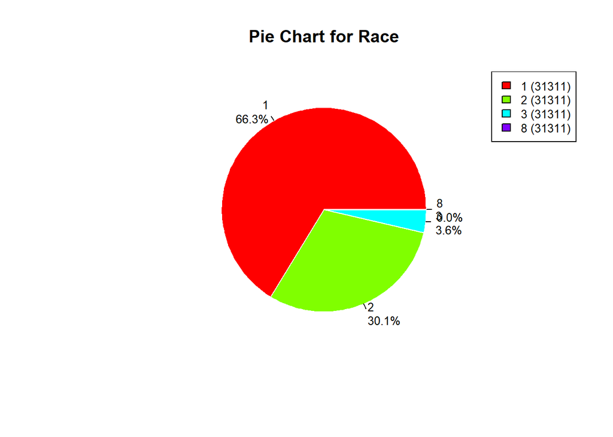

```r
# Removing Missing values Columns

boneExam_ds <- boneExam_ds[,!(names(boneExam_ds) %in% c("DRPNKCAL","MYPB1","MYPB2","MYPB3","MYPB4","MYPB5","MYPB6R","MYPB7R","MYPB8","MYPB9S","MYPB10","MYPB11","MYPB12","MYPB13S","MYPB14","MYPC17"))]

# 1- Counting each individuals for Demographic characteristics (sex, race, and ethnicity) and plotting them for visual representation.

race_counts <- table(boneExam_ds$DMARACER)
sex_counts <- table(boneExam_ds$HSSEX)
ethnicity_counts <- table(boneExam_ds$DMAETHNR)

custom_piechart <- function(counts, title) {
  colors <- rainbow(length(counts))
  percentages <- prop.table(counts) * 100
  pie(counts, main = title, labels = sprintf("%s\n%.1f%%", names(counts), percentages), col = colors, cex = 0.8, border = "white")
  legend("topright", legend = sprintf("%s (%d)", names(counts), sum(counts)), fill = colors, cex = 0.8)
}

custom_piechart(race_counts, "Pie Chart for Race")
```

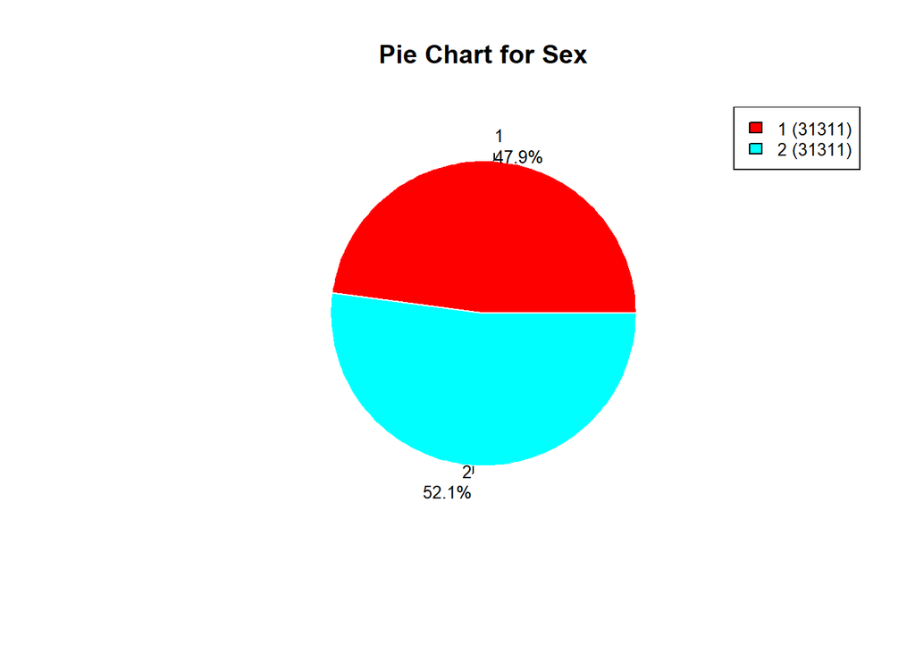

```r
custom_piechart(sex_counts, "Pie Chart for Sex")
```

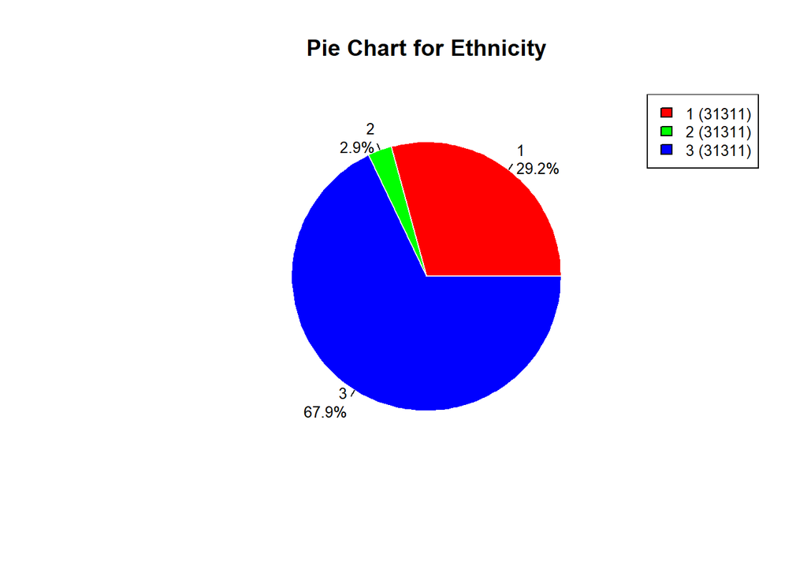

```r
custom_piechart(ethnicity_counts, "Pie Chart for Ethnicity")
```

Pie Charts above provides us the basic analysis of the counts of individuals in different categories based on variables related to Race, Sex, and Ethnicity. Providing visual representations of the distribution of individuals across categories.

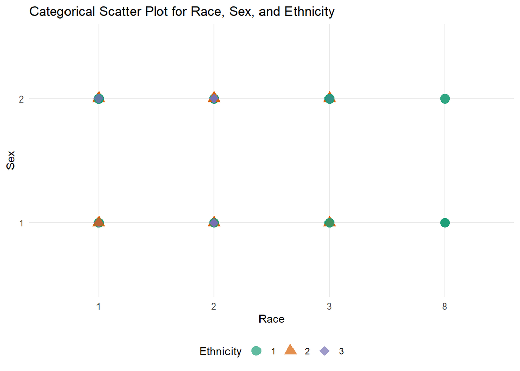

```r
boneExam_cat <- data.frame(
  Race = factor(boneExam_ds$DMARACER),
  Sex = factor(boneExam_ds$HSSEX),
  Ethnicity = factor(boneExam_ds$DMAETHNR)
)

# Create the scatter plot
ggplot(boneExam_cat, aes(x = Race, y = Sex, color = Ethnicity, shape = Ethnicity)) +
  geom_point(size = 4, alpha = 0.7) +
  labs(title = "Categorical Scatter Plot for Race, Sex, and Ethnicity",
       x = "Race",
       y = "Sex",
       color = "Ethnicity",
       shape = "Ethnicity") +
  theme_minimal() +
  theme(legend.position = "bottom") +
  scale_color_manual(values = c("#1b9e77", "#d95f02", "#7570b3")) +
  scale_shape_manual(values = c(16, 17, 18)) +
  guides(alpha = FALSE)
```

Categorical scatter plot above, visualizes the relationship between the Race and Sex variables, with points differentiated by both color and shape based on the Ethnicity variable.

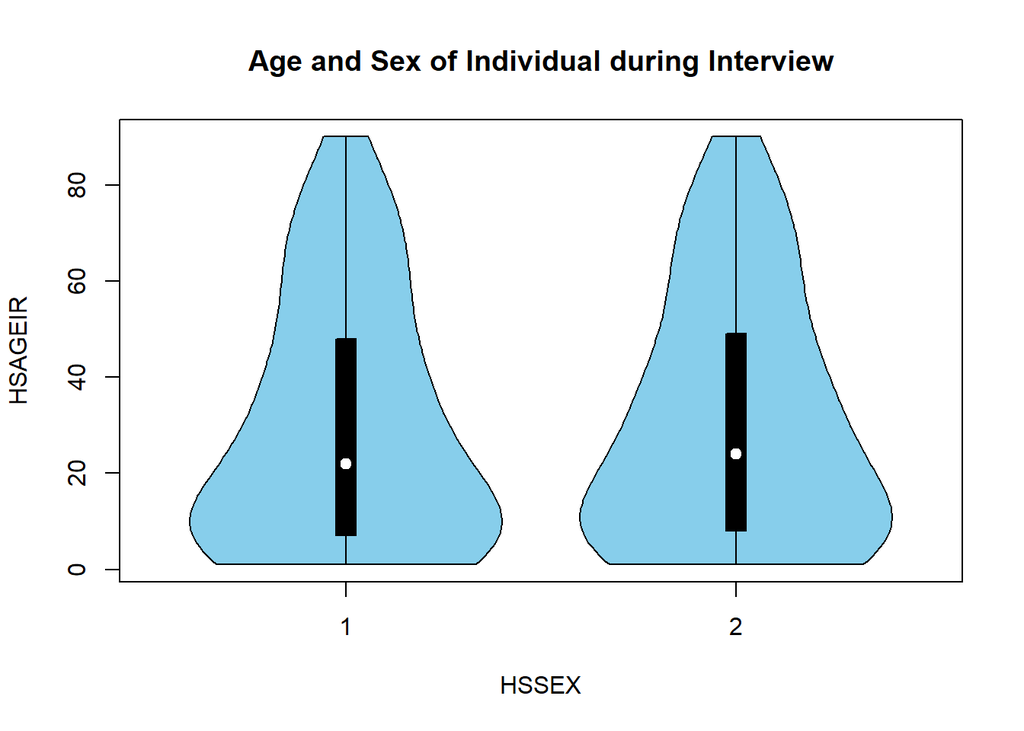

```r
# 2. Visualizing the Age and Gender of Individuals during Interview.

vioplot(HSAGEIR ~ HSSEX, data = boneExam_ds, col = "skyblue",
        fill = "skyblue", main = "Age and Sex of Individual during Interview")
```

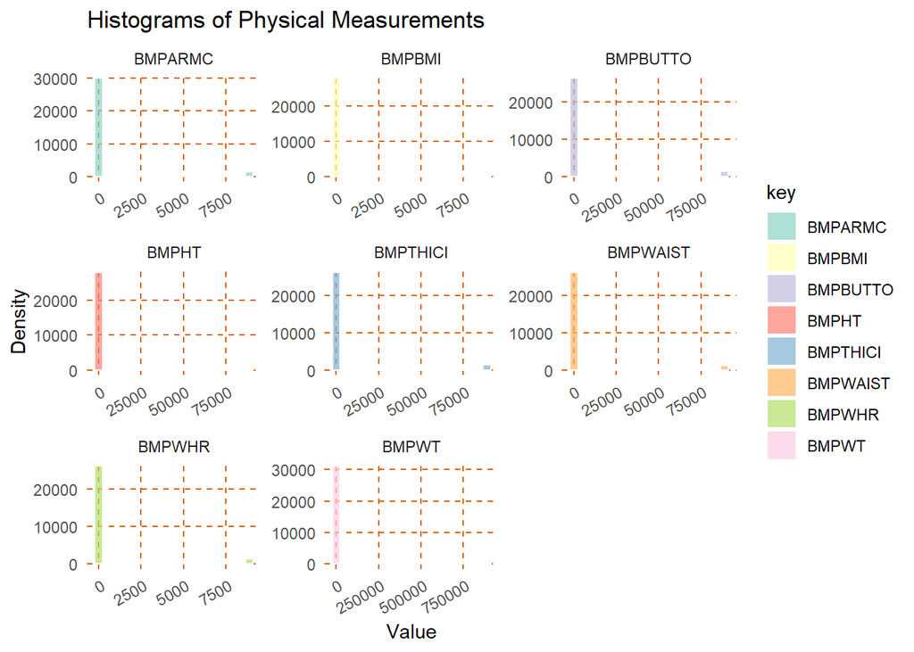

```r
# 3. Visulaizing the 8 Anthropometric measurements such as (weight, body mass index,...,Thigh Circumference) to see the overall distribution.

boneExam_measures <- boneExam_ds[, c(7, 8, 9, 10, 11, 12, 13, 14)]
boneExam_measures_long <- gather(boneExam_measures)

# Create a facetted histogram
ggplot(boneExam_measures_long, aes(x = value, fill = key)) +
  geom_histogram(bins = 20, alpha = 0.7, color = "white", position = "identity") +
  facet_wrap(~key, scales = "free") +
  scale_fill_brewer(palette = "Set3") +  # Use a color palette
  labs(title = "Histograms of Physical Measurements",
       x = "Value",
       y = "Density") +
  theme_minimal() +  # Use a minimal theme
  theme(axis.text.x = element_text(angle = 30, hjust = 1),
        panel.grid.major = element_line(color = "#d95f02", linetype = 2),
        panel.grid.minor = element_blank()) +
  geom_vline(xintercept = mean(boneExam_measures_long$value), color = "blue", linetype = "dashed")
```

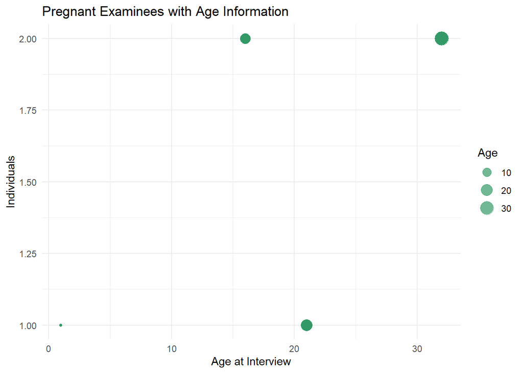

```r
# 4. Visualize the Pregnant Examinee with their Age(s) at Interview and by Race-Ethnicity.

pregnant_examinees <- boneExam_ds[boneExam_ds$PEPPREG, ]

# Create a scatter plot with age information
ggplot(pregnant_examinees, aes(x = HSAGEIR, y = HSSEX, size = HSAGEIR)) +
  geom_point(alpha = 0.7, color = "#339966") +  # Adjust point color
  labs(title = "Pregnant Examinees with Age Information",
       x = "Age at Interview",
       y = "Individuals",
       size = "Age") +
  theme_minimal() +
  theme(legend.position = "right")
```

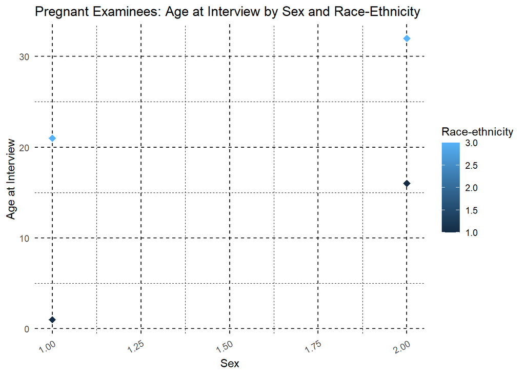

```r
point_style <- "diamond"
point_size <- 3
grid_line_color <- "#000000"

ggplot(pregnant_examinees, aes(x = HSSEX, y = HSAGEIR, color = DMARETHN)) +
  geom_point(alpha = 0.5, shape = point_style, size = point_size) +
  labs(title = "Pregnant Examinees: Age at Interview by Sex and Race-Ethnicity",
       x = "Sex",
       y = "Age at Interview",
       color = "Race-ethnicity") +
  theme_minimal() +
  theme(panel.grid.major = element_line(color = grid_line_color, linetype = 2),
        panel.grid.minor = element_line(color = grid_line_color, linetype = 2),
        axis.text.x = element_text(angle = 30, hjust = 1)) +
  geom_hline(yintercept = mean(pregnant_examinees$HSAGEIR),
              color = "blue", linetype = "dashed")
```

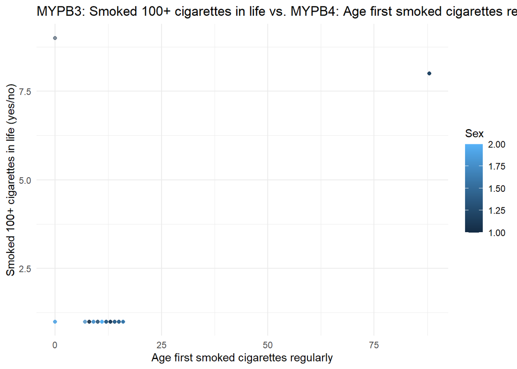

```r
# 5. Whole Analysis on Smoking History of the Individual(s).

boneExam_ds <- read.csv("boneExam.csv")

# Scatter plot: MYPB3 vs. MYPB4

ggplot(boneExam_ds, aes(x = MYPB4, y = MYPB3, color = HSSEX)) +
  geom_point(alpha = 0.5) +
  labs(title = "MYPB3: Smoked 100+ cigarettes in life vs. MYPB4: Age first smoked cigarettes regularly",
       x = "Age first smoked cigarettes regularly",
       y = "Smoked 100+ cigarettes in life (yes/no)",
       color = "Sex") +
  theme_minimal()
```

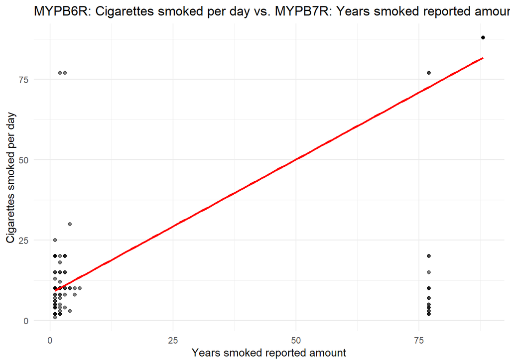

```r
# Scatter plot: MYPB6R vs. MYPB7R

ggplot(boneExam_ds, aes(x = MYPB7R, y = MYPB6R)) +
  geom_point(alpha = 0.5) +
  labs(title = "MYPB6R: Cigarettes smoked per day vs. MYPB7R: Years smoked reported amount",
       x = "Years smoked reported amount",
       y = "Cigarettes smoked per day") +
  theme_minimal()+geom_smooth(method = "lm", color = "red", se = FALSE)
```

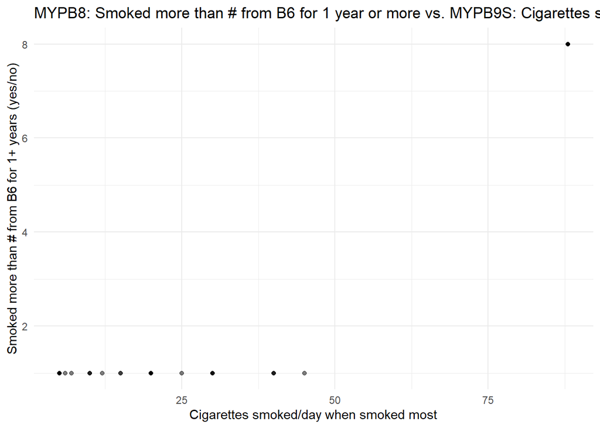

```r
# Scatter plot: MYPB8 vs. MYPB9S

ggplot(boneExam_ds, aes(x = MYPB9S, y = MYPB8)) +
  geom_point(alpha = 0.5) +
  labs(title = "MYPB8: Smoked more than # from B6 for 1 year or more vs. MYPB9S: Cigarettes smoked/day when smoked most",
       x = "Cigarettes smoked/day when smoked most",
       y = "Smoked more than # from B6 for 1+ years (yes/no)") +
  theme_minimal()
```

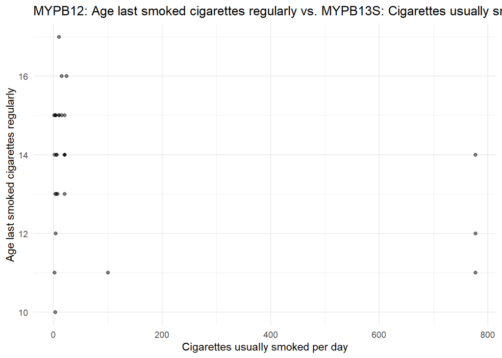

```r
# Scatter plot: MYPB12 vs. MYPB13S

ggplot(boneExam_ds, aes(x = MYPB13S, y = MYPB12)) +
  geom_point(alpha = 0.5) +
  labs(title = "MYPB12: Age last smoked cigarettes regularly vs. MYPB13S: Cigarettes usually smoked per day",
       x = "Cigarettes usually smoked per day",
       y = "Age last smoked cigarettes regularly") +
  theme_minimal()
```

Plot above explores the relationship between the age last smoked cigarettes regularly (MYPB12) and the usual number of cigarettes smoked per day (MYPB13S). It aims to identify any potential trends between age and smoking habits.

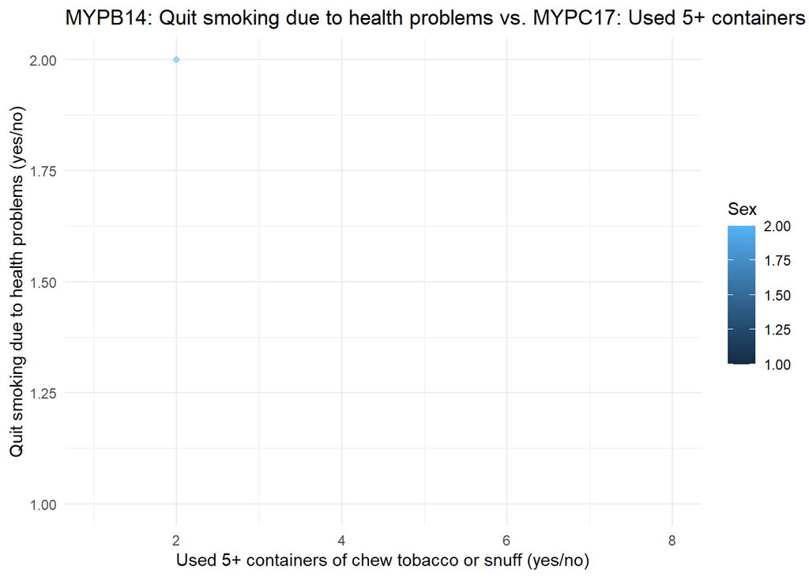

```r
# Scatter plot: MYPB14 vs. MYPC17

ggplot(boneExam_ds, aes(x = MYPC17, y = MYPB14, color = HSSEX)) +
  geom_point(alpha = 0.5) +
  labs(title = "MYPB14: Quit smoking due to health problems vs. MYPC17: Used 5+ containers of chew tobacco or snuff",
       x = "Used 5+ containers of chew tobacco or snuff (yes/no)",
       y = "Quit smoking due to health problems (yes/no)",
       color = "Sex") +
  theme_minimal()
```

Plot above investigates the relationship between quitting smoking due to health problems (MYPB14) and using 5 or more containers of chew tobacco or snuff (MYPC17).The color coding again distinguishes between males and females to assess potential differences in this relationship for each sex.

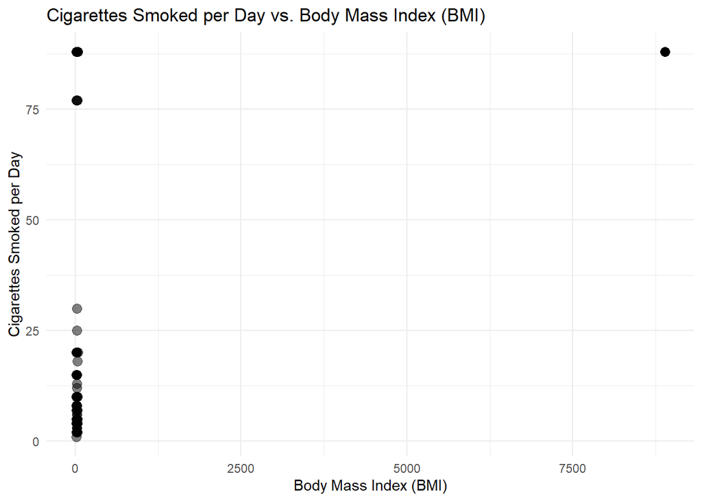

```r
# 6. Comparison of Smoking variables with other Health Measures like BMI and Food intake by Quitting Smoking.

boneExam_ds <- read.csv("boneExam.csv")

# MYPB6R vs. BMPBMI: Cigarettes per Day and Body Mass Index

ggplot(boneExam_ds, aes(x = BMPBMI, y = MYPB6R)) +
  geom_point(alpha = 0.5, size = 3) +
  labs(title = "Cigarettes Smoked per Day vs. Body Mass Index (BMI)",
       x = "Body Mass Index (BMI)",
       y = "Cigarettes Smoked per Day") +
  theme_minimal()
```

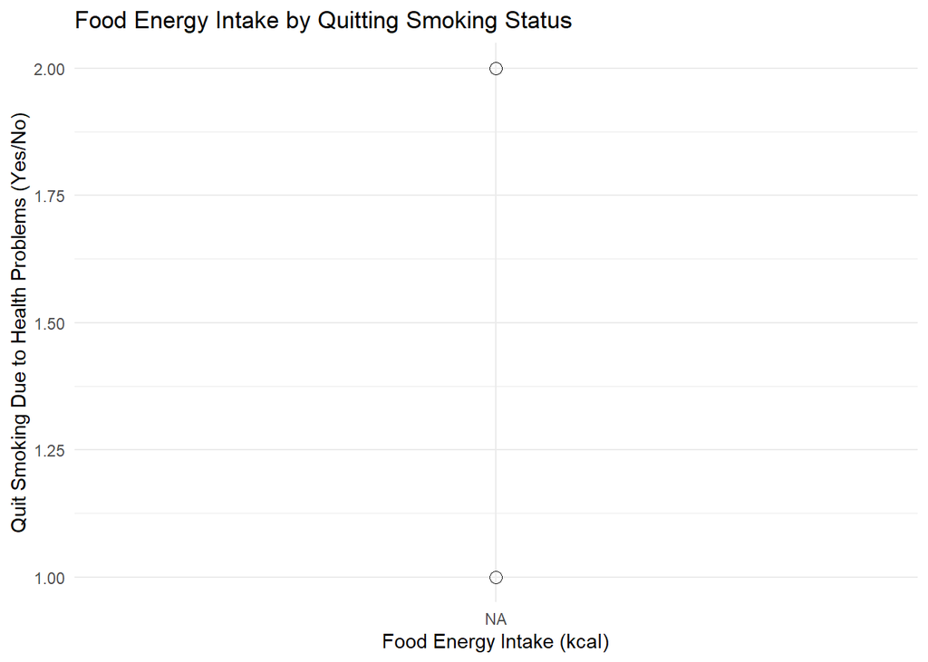

```r
# MYPB14 vs. DRPNKCAL: Quitting Smoking and Food Energy Intake

ggplot(boneExam_ds, aes(x = DRPNKCAL, y = MYPB14)) +
  geom_point(alpha = 0.5, shape = 1, size = 3) +
  labs(title = "Food Energy Intake by Quitting Smoking Status",
       x = "Food Energy Intake (kcal)",
       y = "Quit Smoking Due to Health Problems (Yes/No)") +
  theme_minimal()
```

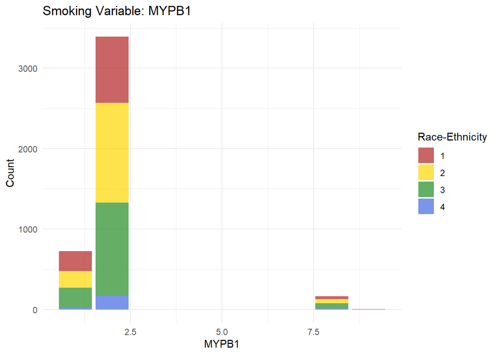

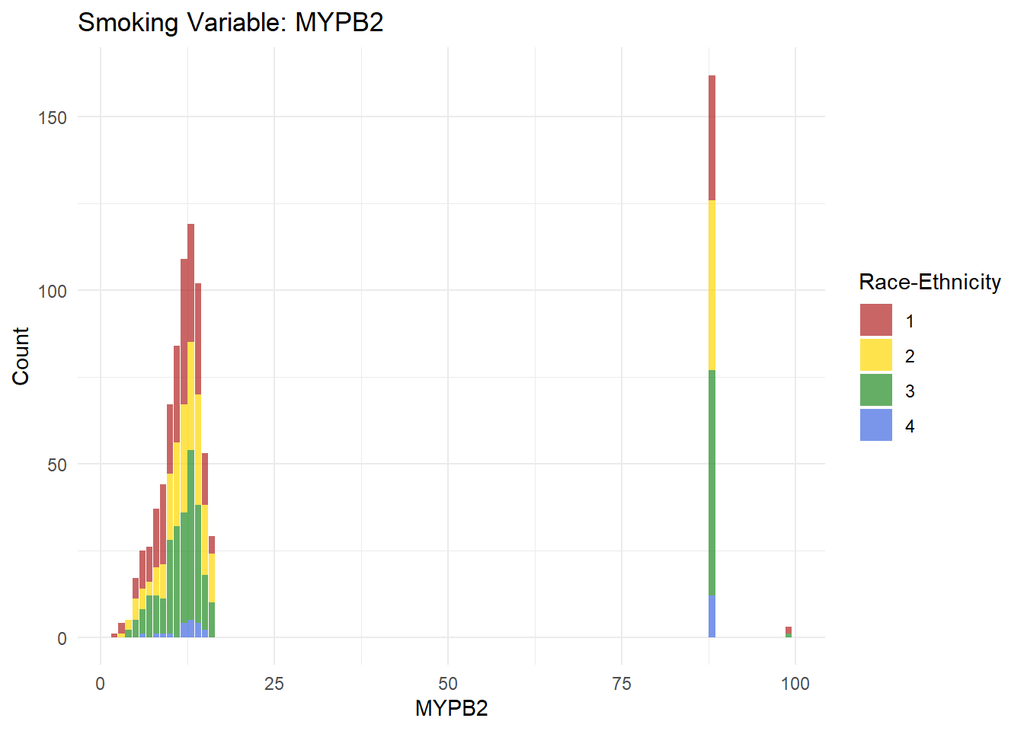

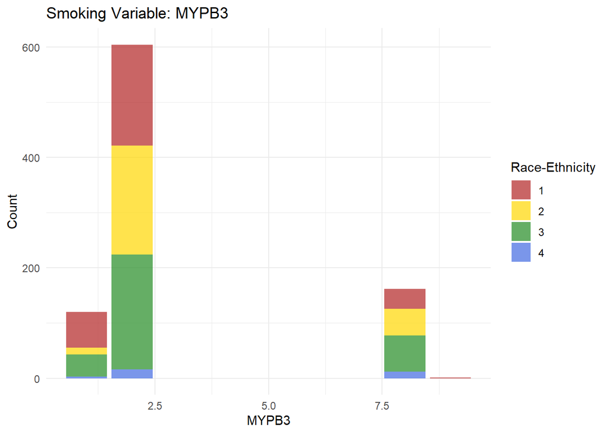

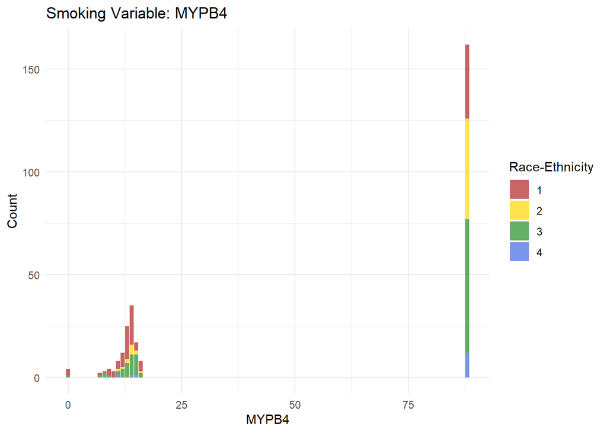

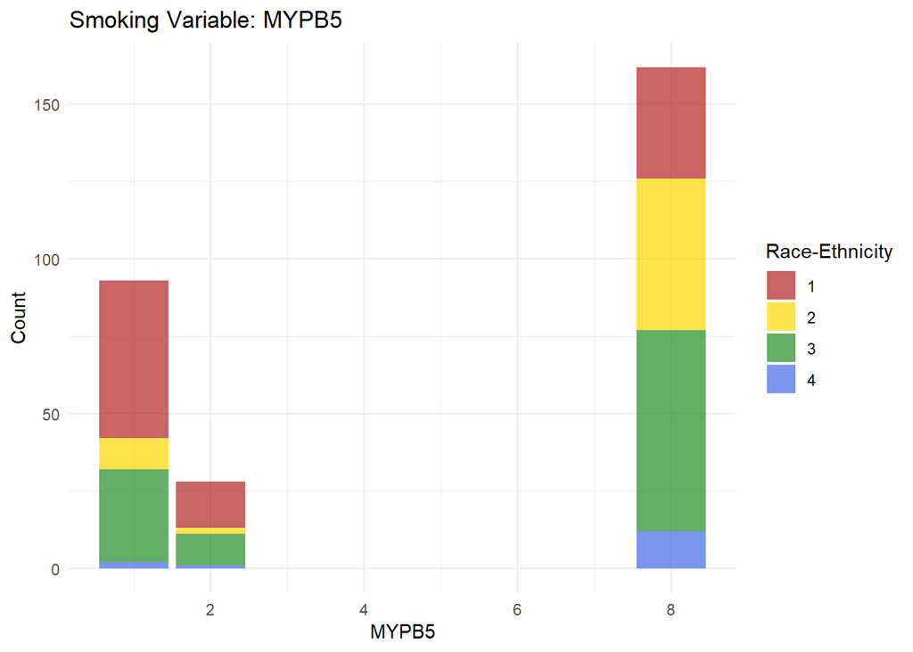

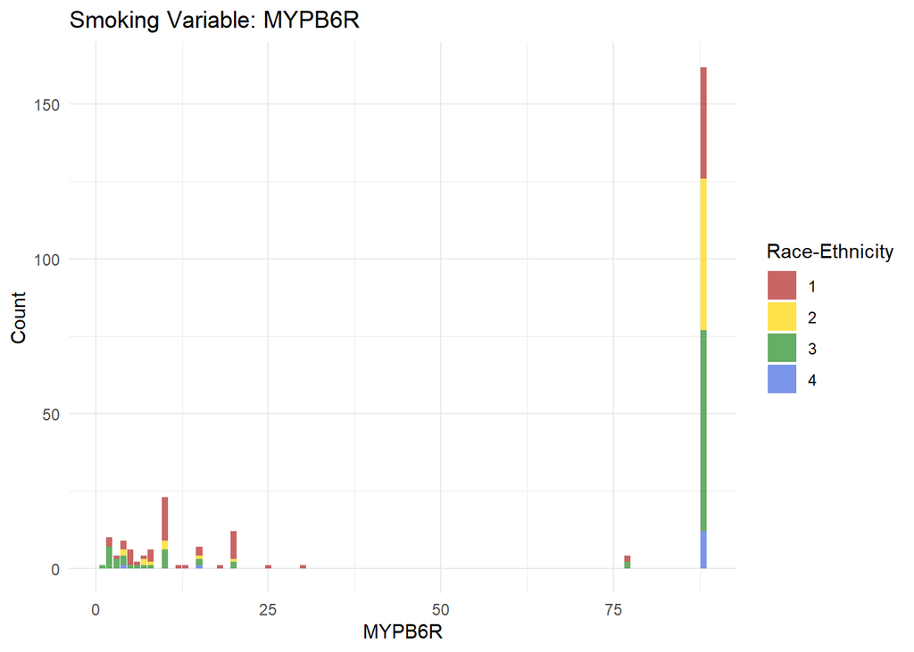

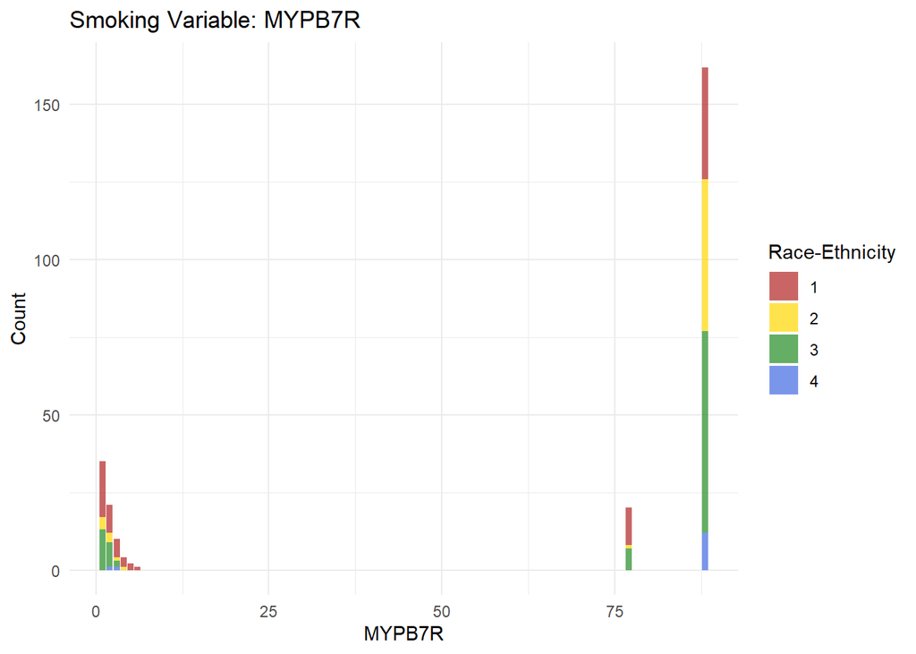

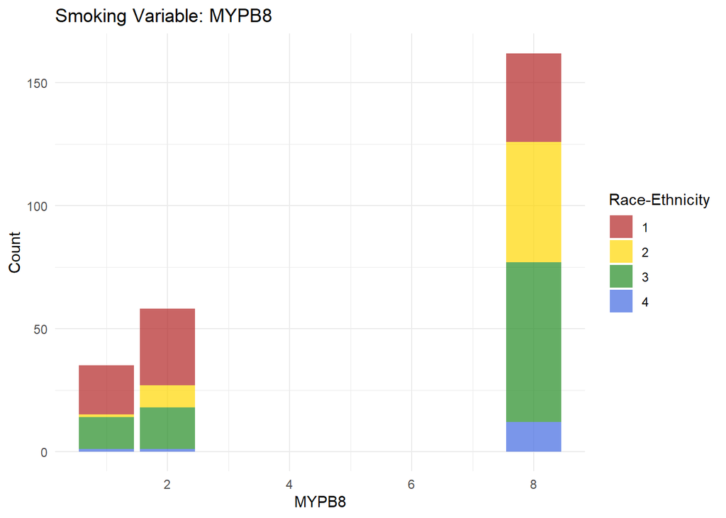

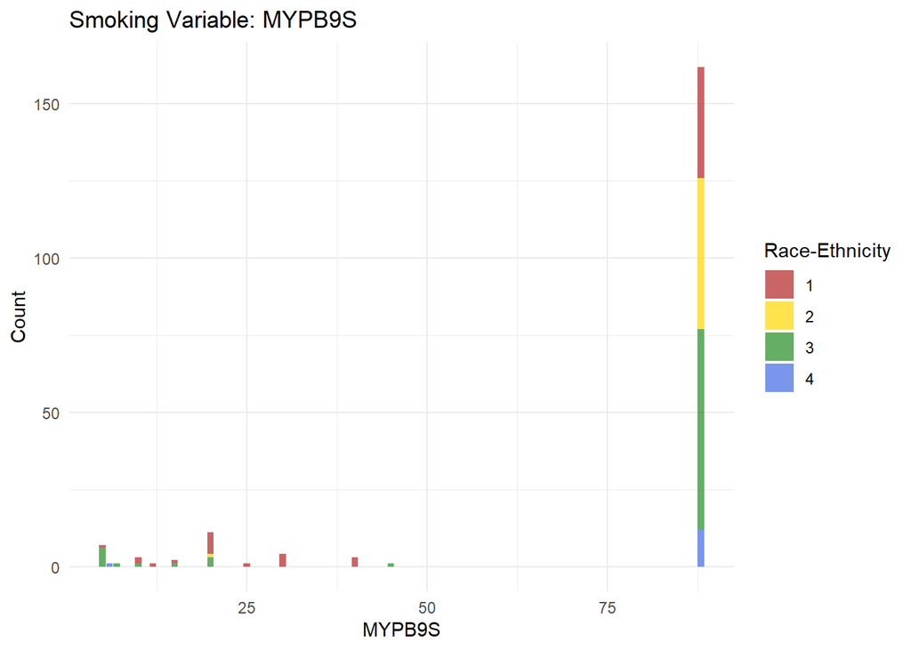

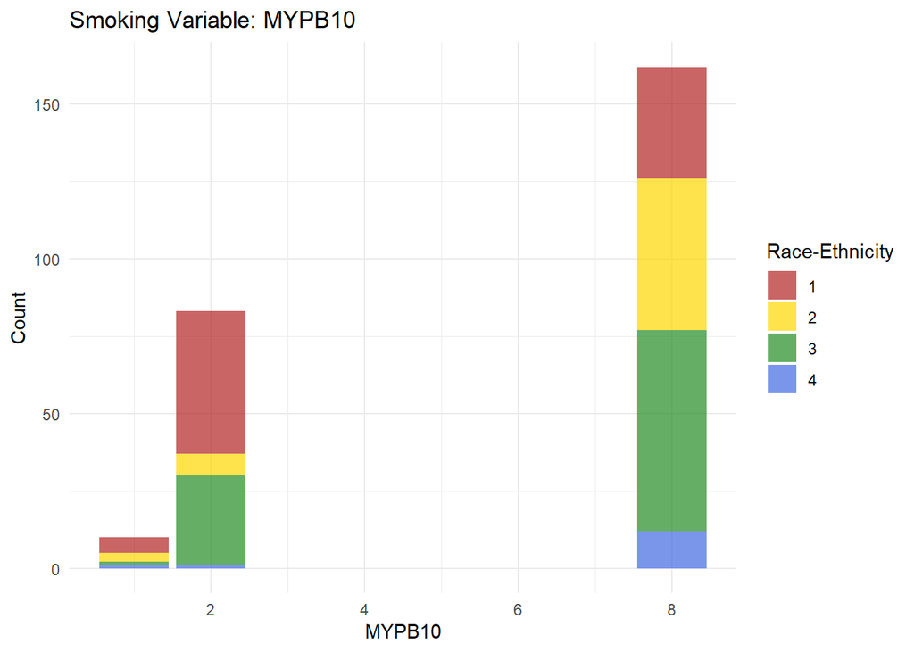

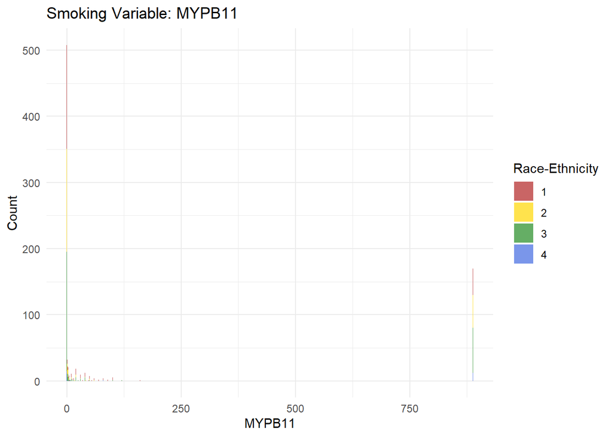

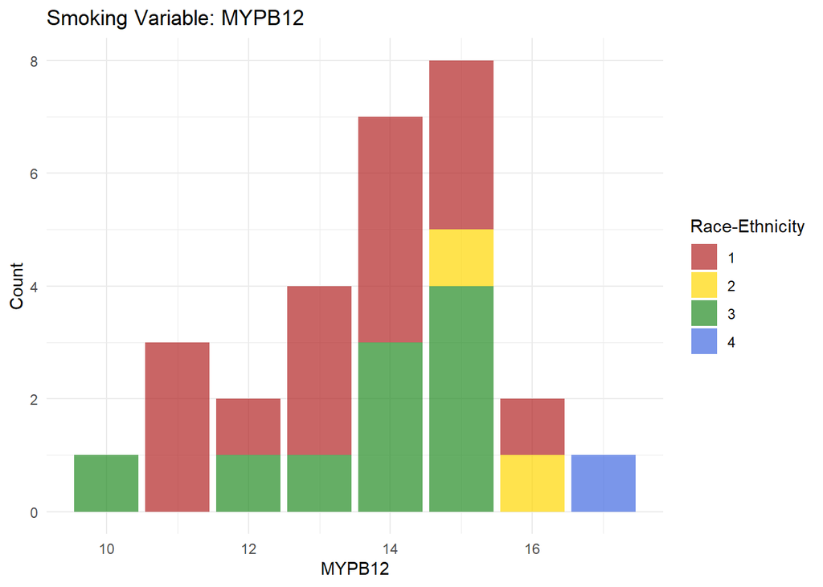

[3 more figures not shown]

```r
# 7. Exploring the relation of all smoking variables with Demographic characteristics (sex, race, ethnicity).

boneExam_ds <- read.csv("boneExam.csv")

# Define colors for sex and race-ethnicity

sex_colors <- c("coral", "skyblue")

race_ethnicity_colors <- c("firebrick", "gold", "forestgreen", "royalblue", "purple", "magenta")

boneExam_smoking <- c("MYPB1", "MYPB2", "MYPB3", "MYPB4", "MYPB5", "MYPB6R", "MYPB7R", "MYPB8", "MYPB9S", "MYPB10", "MYPB11", "MYPB12", "MYPB13S", "MYPB14", "MYPC17")

# Create separate plots for each smoking variable, color-coded by race-ethnicity

for (smoking_var in boneExam_smoking) {
  print(ggplot(boneExam_ds, aes(x = !!sym(smoking_var), fill = factor(DMARETHN))) +
    geom_bar(position = "stack", alpha = 0.7) +
    scale_fill_manual(values = race_ethnicity_colors, name = "Race-Ethnicity") +
    labs(title = paste("Smoking Variable:", smoking_var),
         x = smoking_var,
         y = "Count") +
    theme_minimal())
}
```

Similar to the first set of plots, but color-coded by race-ethnicity instead of sex. Each bar plot represents a different smoking variable. The x-axis represents the values of the smoking variable. The y-axis represents the count or frequency of each value. Bars are stacked, and each segment of the bar corresponds to a different race-ethnicity category. Different colors (firebrick, gold, forestgreen, royalblue, purple, magenta) are used to distinguish between different race-ethnicity categories.

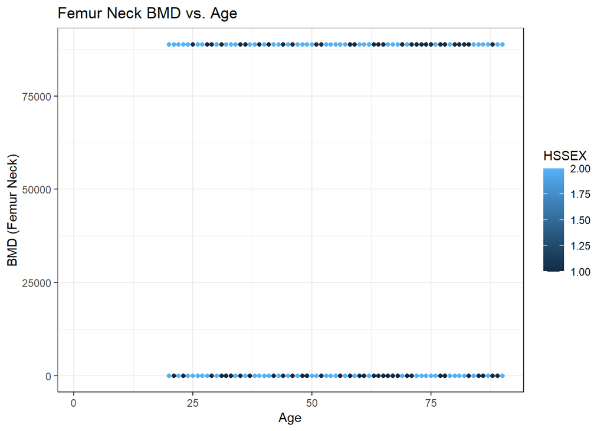

```r
# 8. Analysis the relationship b/w age and Anthropometric measurements (weight, body mass index, ... ,Thigh Circumference).

age_groups <- cut(boneExam_ds$HSAGEIR, breaks = 10)
average_bmd_by_age <- aggregate(cbind(BDPFNBMD, BDPTRBMD, BDPINBMD, BDPTOBMD) ~ HSSEX + age_groups, boneExam_ds, FUN = mean)

# Plot age vs. BMD for each region by sex
ggplot(boneExam_ds, aes(x = HSAGEIR, y = BDPFNBMD, color = HSSEX)) +
  geom_point() +
  labs(title = "Femur Neck BMD vs. Age", x = "Age", y = "BMD (Femur Neck)") +
  theme_bw() +
  scale_x_continuous(limits = c(min(boneExam_ds$HSAGEIR), max(boneExam_ds$HSAGEIR))) +
  scale_y_continuous(limits = c(min(boneExam_ds$BDPFNBMD), max(boneExam_ds$BDPFNBMD)))
```

It calculates the age-specific average BMD for each of the four bone regions (femur neck, trochanter, intertrochanter, and total) by dividing the data into age groups. This helps us visualize and analyze the potential age-related decline in BMD for each region separately. The code also plots the age vs. BMD for femur neck by sex, allowing us to visually compare the trends between men and women.

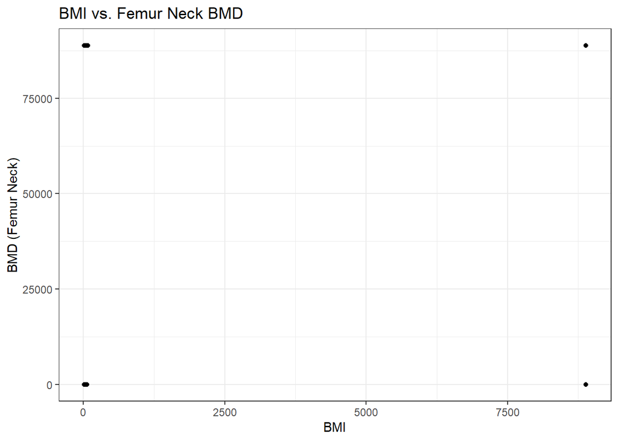

```r
# 9. Analysis of Anthropometric measurements with different sex groups.

average_bmd_by_sex <- aggregate(cbind(BDPFNBMD, BDPTRBMD, BDPINBMD, BDPTOBMD) ~ HSSEX, boneExam_ds, FUN = mean)

# It calculates the overall average BMD for each of the four bone regions for both men and women. Comparing these averages allows us to see if there are significant differences in BMD between sexes. The code also suggests performing statistical tests (e.g., t-test) to confirm these differences with more statistical rigor.

# Compare BMD between sexes using appropriate tests (e.g., t-test) and Investigate the influence of body composition factors on BMD.

# Create correlation plots between BMD regions and body composition factors

ggplot(boneExam_ds, aes(x = BMPBMI, y = BDPFNBMD)) +
  geom_point() +
  labs(title = "BMI vs. Femur Neck BMD", x = "BMI", y = "BMD (Femur Neck)") +
  theme_bw() +
  scale_x_continuous(limits = c(min(boneExam_ds$BMPBMI), max(boneExam_ds$BMPBMI))) +
  scale_y_continuous(limits = c(min(boneExam_ds$BDPFNBMD), max(boneExam_ds$BDPFNBMD)))
```

```r
# 10. Exploring the impact of Race-ethnicity on Anthropometric measurements.

# Calculate BMD averages by race/ethnicity

average_bmd_by_ethnicity <- aggregate(cbind(BDPFNBMD, BDPTRBMD, BDPINBMD, BDPTOBMD) ~ DMARETHN, boneExam_ds, FUN = mean)

#  It calculates the average BMD for each of the four bone regions across different ethnicities. This helps us identify potential disparities in BMD between different ethnic groups.The code also suggests performing statistical tests (e.g., ANOVA) to assess the significance of these differences. Analyze potential interactions between variables (e.g., sex and age) on BMD using appropriate models (e.g., linear regression ")


# 11. Exploring the Correlation Analysis b/w Anthropometric measurements.

boneExam_subset <- boneExam_ds[, c("BMPBMI", "BMPWHR", "BMPARMC", "BMPTHICI", "BDPFNBMD", "BDPTRBMD", "BDPINBMD", "BDPTOBMD")]

# Correlation analysis
correlations <- cor(boneExam_subset, use = "pairwise.complete.obs")
print(correlations)
```

```
##              BMPBMI    BMPWHR   BMPARMC  BMPTHICI   BDPFNBMD   BDPTRBMD
## BMPBMI   1.00000000 0.2653385 0.2673210 0.2586323 0.06775302 0.06775305
## BMPWHR   0.26533851 1.0000000 0.8979408 0.9067757 0.32402471 0.32402474
## BMPARMC  0.26732095 0.8979408 1.0000000 0.8792998 0.30029760 0.30029763
## BMPTHICI 0.25863229 0.9067757 0.8792998 1.0000000 0.31619752 0.31619756
## BDPFNBMD 0.06775302 0.3240247 0.3002976 0.3161975 1.00000000 1.00000000
## BDPTRBMD 0.06775305 0.3240247 0.3002976 0.3161976 1.00000000 1.00000000
## BDPINBMD 0.06775300 0.3240247 0.3002976 0.3161975 1.00000000 1.00000000
## BDPTOBMD 0.06775302 0.3240247 0.3002976 0.3161975 1.00000000 1.00000000
##           BDPINBMD   BDPTOBMD
## BMPBMI   0.0677530 0.06775302
## BMPWHR   0.3240247 0.32402469
## BMPARMC  0.3002976 0.30029758
## BMPTHICI 0.3161975 0.31619751
## BDPFNBMD 1.0000000 1.00000000
## BDPTRBMD 1.0000000 1.00000000
## BDPINBMD 1.0000000 1.00000000
## BDPTOBMD 1.0000000 1.00000000
```

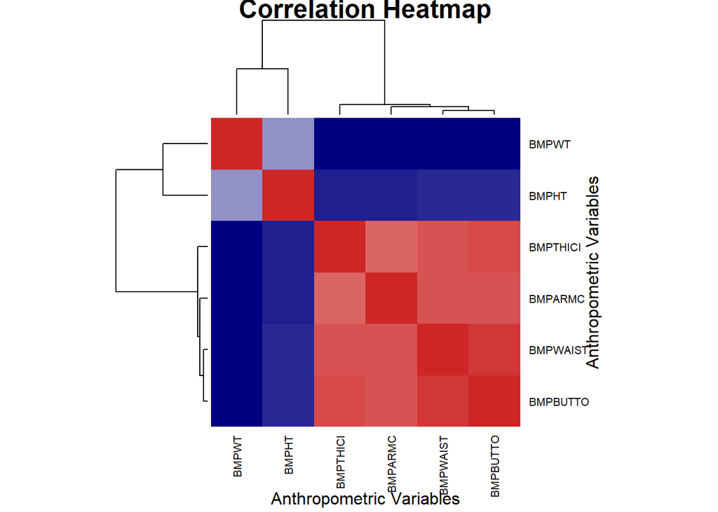

```r
#  It selects a subset of columns containing body composition factors (BMI, WHR, arm circumference, thigh circumference) and BMD measurements for different regions (femur neck, trochanter, intertrochanter, total).It calculates the pairwise correlations between all the selected variables using the cor function. The use of pairwise.complete.obs argument ensures that only subjects with complete data are included in the analysis.


anthropometry_subset <- boneExam_ds[, c("BMPWT", "BMPHT", "BMPARMC", "BMPWAIST", "BMPBUTTO", "BMPTHICI")]

# Calculate correlations
correlation_matrix <- cor(anthropometry_subset, use = "pairwise.complete.obs")

# Using heatmap

heatmap(correlation_matrix,
        main = "Correlation Heatmap",
        xlab = "Anthropometric Variables",
        ylab = "Anthropometric Variables",
        col = colorRampPalette(c("navy", "white", "firebrick3"))(50),
        scale = "none",  # To disable the scale
        symm = TRUE,      # To make the plot symmetric
        margins = c(5, 5), # To add some space for labels
        cexCol = 0.8,    # Adjust the size of column labels
        cexRow = 0.8,    # Adjust the size of row labels
        key.title = NA   # Remove the title of the color key
)
```

```r
# 12. Predicting the Bone Mineral Density (BMD) using demographic and anthropometric factors using Linear Regression Model. Training, Testing and Evaluating the prediction of my model.

# Select relevant features for prediction

features <- c("HSAGEIR", "HSSEX", "BMPBMI", "BMPWHR", "BMPARMC", "BMPTHICI")

# Prepare the target variable
target <- boneExam_ds$BDPFNBMD

# Split the data into training and testing sets

set.seed(123)
train_index <- sample(1:nrow(boneExam_ds), floor(0.7 * nrow(boneExam_ds)))
train_data <- boneExam_ds[train_index, c(features, "BDPFNBMD")]
test_data <- boneExam_ds[-train_index, c(features, "BDPFNBMD")]
train_data <- na.omit(train_data)
test_data <- na.omit(test_data)

# Choose a model and train it

linear_model <- lm(BDPFNBMD ~ ., data = train_data, na.action = na.exclude)

# Evaluate the model
predictions <- predict(linear_model, newdata = test_data)
rmse <- sqrt(mean((predictions - test_data$BDPFNBMD)^2))

cat("Root Mean Squared Error (RMSE):", rmse)
```

```
## Root Mean Squared Error (RMSE): 26201.69
```

Features variable selects relevant factors for predicting BMD: age, sex, BMI, WHR, arm circumference, and thigh circumference. Target defines the target variable as femur neck BMD (BDPFNBMD). Train_index randomly splits the data into training and testing sets (70% training, 30% testing). Train_data and test_data subset the data with selected features and target variable based on the split.

na.omit removes rows with missing values in both training and testing datasets.

Lm builds a linear regression model predicting BDPFNBMD using all training data features. na.action = na.exclude instructs the model to ignore rows with missing values during training. Predict uses the trained model to predict BMD on the test data features. Rmse calculates the root mean squared error (RMSE) between predicted and actual BMD values in the test set.

A lower RMSE indicates better model performance. In this case, an RMSE of 26201 suggests that the model’s predictions deviate significantly from the actual BMD values, on average.

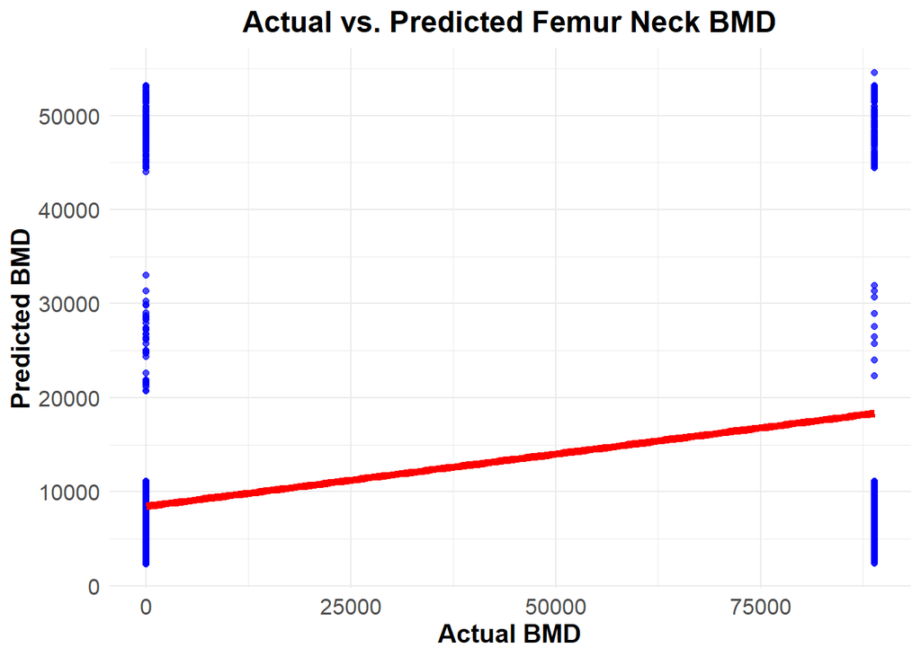

```r
# Extract predictions and actual BMD

predictions <- predict(linear_model, newdata = test_data)
actual_bmd <- test_data$BDPFNBMD

theme_set(theme_minimal())
ggplot(data.frame(actual_bmd, predictions), aes(x = actual_bmd, y = predictions)) +
  geom_point(color = "blue", alpha = 0.7) +
  geom_smooth(method = "lm", se = FALSE, color = "red", lwd = 2) +
  labs(title = "Actual vs. Predicted Femur Neck BMD",
       x = "Actual BMD",
       y = "Predicted BMD") +
  theme_minimal() +
  theme(axis.text = element_text(size = 12),
        axis.title = element_text(size = 14, face = "bold"),
        plot.title = element_text(size = 16, face = "bold", hjust = 0.5),
        legend.position = "none")
```

```r
annotate("text", x = max(actual_bmd) - 0.1, y = max(predictions) - 0.1,
         label = paste("RMSE:", round(rmse, 2)), color = "red", size = 4)
```

```
## mapping: x = ~x, y = ~y
## geom_text: na.rm = FALSE
## stat_identity: na.rm = FALSE
## position_identity
```

```r
# 13. Comparing the average BMD across all ethnic groups and visualizing the distributions.

# Calculate and display the average BMD for each racial/ethnic group

# Convert DMARETHN to factor with explicit levels and Convert DMARETHN to a factor with meaningful labels

boneExam_ds$DMARETHN <- factor(boneExam_ds$DMARETHN, levels = c(1, 2, 3, 4, 9), labels = c("Level 1", "Level 2", "Level 3", "Level 4", "Level 9"))

bmd_by_race <- aggregate(BDPFNBMD ~ DMARETHN, data = boneExam_ds, FUN = mean)

# Print the summary of average BMD by race/ethnicity

print("Average BMD by Race/Ethnicity:")
```

```
## [1] "Average BMD by Race/Ethnicity:"
```

```r
print(bmd_by_race)
```

```
##   DMARETHN  BDPFNBMD
## 1  Level 1  7215.339
## 2  Level 2 11205.982
## 3  Level 3 11600.059
## 4  Level 4  8875.884
```

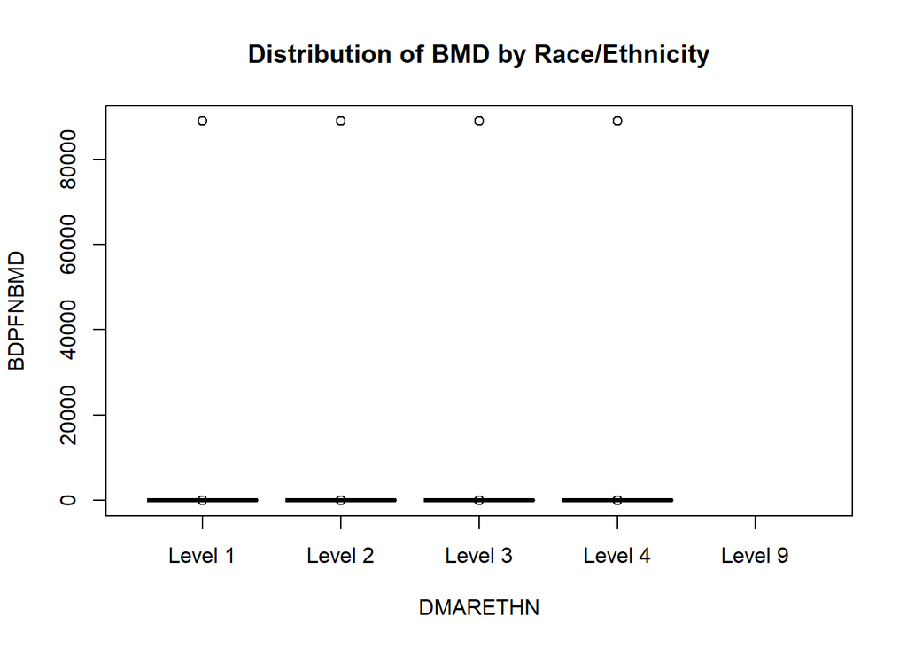

```r
# Visualize the distribution of BMD within each group Boxplot

boxplot(BDPFNBMD ~ DMARETHN, data = boneExam_ds)
title("Distribution of BMD by Race/Ethnicity")
mtext("", side = 1, line = 3)  # Label for the x-axis
mtext("", side = 2, line = 3)  # Label for the y-axis
```